# Analisis de los trayectos de taxis de NY

Daniel Arellano Martínez, Bruno González Llaga, Carlos González Arenas, Diego Monsalves Vázquez y Víctor Manuel Vázquez García

# Introducción

Los taxis de New York son una forma común de transporte en la ciudad. Están disponibles en toda la ciudad y pueden ser reconocidos por su característica pintura amarilla.

Los conductores de taxis de Nueva York deben tener una licencia especial y una tarjeta de identificación, y los vehículos deben pasar inspecciones regulares para asegurar la seguridad de los pasajeros.

Los pasajeros pueden solicitar un taxi en la calle, a través de una aplicación móvil o en una parada de taxi designada. Los taxis también pueden ser contratados para viajes más largos fuera de la ciudad.

A continuación, se va a analizar el dataset “train” sobre los trayectos de taxis que incluirá los siguientes datos:

- `id`: identifica a cada viaje
- `vendor_id`: identifica al proveedor que ofrece el servicio
- `pickup_datetime`: fecha y hora de recogida
- `dropoff_datetime`: fecha y hora de llegada
- `passenger_count`: número de pasajeros (incluyendo el conductor)
- `pickup_longitude`: longitud donde el pasajero es recogido
- `pickup_latitude`: latitud donde el pasajero es recogido
- `dropoff_longitude`: longitud donde el pasajero termina el trayecto
- `dropoff_latitude`: latitud donde el pasajero termina el trayecto
- `store_and_fwd_flag`: indica si ha perdido la conexión con el servidor y se ha almacenado localmente
- `trip_duration`: duración del viaje en segundos

Este análisis del dataset de taxis de Nueva York se centrará en examinar las tendencias y patrones en el uso de los taxis en la ciudad. A través del análisis de datos como la ubicación y el tiempo de viaje, se espera obtener una mejor comprensión de cómo se utilizan los taxis en Nueva York.

Entrenaremos modelos que permitirán realizar predicciones o clasificaciones de los distintos trayectos.

```r
# importación de paquetes
suppressPackageStartupMessages(library(dplyr))
library(scales)
library(geosphere)
library(pryr)
library(dendextend)
```

```r
library(ggplot2)
library(NbClust)
library(factoextra)
library(dbscan)
library(caret)
library(tidyverse)
library(lubridate)
library(gridExtra)
library("xgboost")
library(randomForest)
```

## Obtención de datos

Este análisis del dataset de taxis de Nueva York se basa en datos extraídos de la plataforma [Kaggle](https://www.kaggle.com/competitions/nyc-taxi-trip-duration/data) en la sección de competiciones. Estos datos han sido descargados y tratados de forma local. Para ello se almacenan en la variable/dataset de R “*train*”.

```r
# dataset de entrenamiento
train <- read.csv("datos/train.csv")

# representa el dataset de entrenamiento
head(train)
```

|  | id | vendor_id | pickup_datetime | dropoff_datetime | passenger_count | pickup_longitude | pickup_latitude | dropoff_longitude | dropoff_latitude | store_and_fwd_flag | trip_duration |
| --- | --- | --- | --- | --- | --- | --- | --- | --- | --- | --- | --- |
| 1 | id2875421 | 2 | 2016-03-14 17:24:55 | 2016-03-14 17:32:30 | 1 | -73.98215 | 40.76794 | -73.96463 | 40.76560 | N | 455 |
| 2 | id2377394 | 1 | 2016-06-12 00:43:35 | 2016-06-12 00:54:38 | 1 | -73.98042 | 40.73856 | -73.99948 | 40.73115 | N | 663 |
| 3 | id3858529 | 2 | 2016-01-19 11:35:24 | 2016-01-19 12:10:48 | 1 | -73.97903 | 40.76394 | -74.00533 | 40.71009 | N | 2124 |
| 4 | id3504673 | 2 | 2016-04-06 19:32:31 | 2016-04-06 19:39:40 | 1 | -74.01004 | 40.71997 | -74.01227 | 40.70672 | N | 429 |
| 5 | id2181028 | 2 | 2016-03-26 13:30:55 | 2016-03-26 13:38:10 | 1 | -73.97305 | 40.79321 | -73.97292 | 40.78252 | N | 435 |
| 6 | id0801584 | 2 | 2016-01-30 22:01:40 | 2016-01-30 22:09:03 | 6 | -73.98286 | 40.74220 | -73.99208 | 40.74918 | N | 443 |

```r
# características básicas del dataset
summary(train)
```

```
##       id              vendor_id     pickup_datetime    dropoff_datetime
##  Length:1458644     Min.   :1.000   Length:1458644     Length:1458644
##  Class :character   1st Qu.:1.000   Class :character   Class :character
##  Mode  :character   Median :2.000   Mode  :character   Mode  :character
##                     Mean   :1.535
##                     3rd Qu.:2.000
##                     Max.   :2.000
##  passenger_count pickup_longitude  pickup_latitude dropoff_longitude
##  Min.   :0.000   Min.   :-121.93   Min.   :34.36   Min.   :-121.93
##  1st Qu.:1.000   1st Qu.: -73.99   1st Qu.:40.74   1st Qu.: -73.99
##  Median :1.000   Median : -73.98   Median :40.75   Median : -73.98
##  Mean   :1.665   Mean   : -73.97   Mean   :40.75   Mean   : -73.97
##  3rd Qu.:2.000   3rd Qu.: -73.97   3rd Qu.:40.77   3rd Qu.: -73.96
##  Max.   :9.000   Max.   : -61.34   Max.   :51.88   Max.   : -61.34
##  dropoff_latitude store_and_fwd_flag trip_duration
##  Min.   :32.18    Length:1458644     Min.   :      1
##  1st Qu.:40.74    Class :character   1st Qu.:    397
##  Median :40.75    Mode  :character   Median :    662
##  Mean   :40.75                       Mean   :    959
##  3rd Qu.:40.77                       3rd Qu.:   1075
##  Max.   :43.92                       Max.   :3526282
```

# Visualización

Empezaremos visualizando cada una de las variables presentes en nuestro dataset, posteriormente realizaremos un preprocesamiento.

Comenzaremos con `vendor_id`, esta variable indica el conductor que realizó el trayecto.

Se puede observar que el taxista 2 dispone de más trayectos que el 1, pero la diferencia es insignificado en comparación a la cantidad de datos existentes.

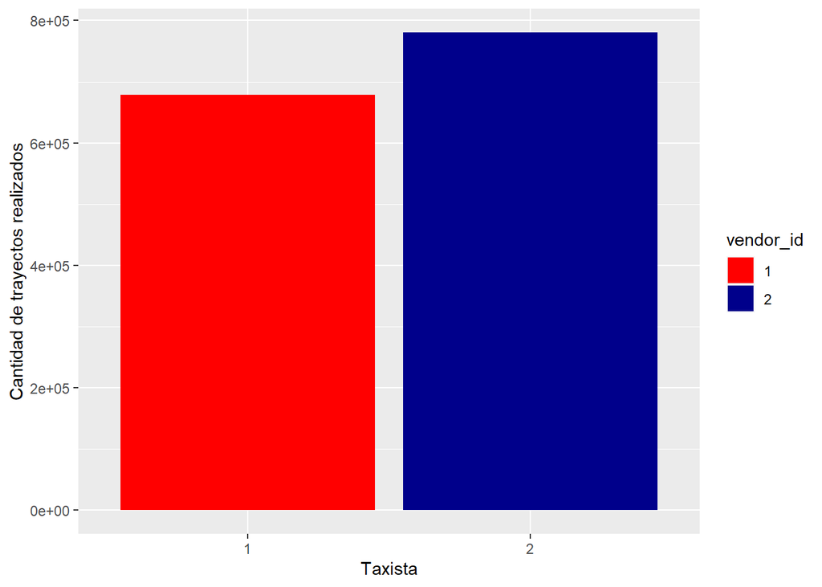

```r
train %>%
  mutate(vendor_id = factor(vendor_id)) %>%
  ggplot(aes(vendor_id, fill = vendor_id)) +
  geom_bar() +
  scale_fill_manual(values=c("red", "darkblue")) +
  labs(x = "Taxista", y = "Cantidad de trayectos realizados")
```

Continuamos con `passenger_count`, que indica la cantidad de personas que se montaron en el taxi.

Se puede observar que la mayoría de trayectos únicamente transportaban una persona.

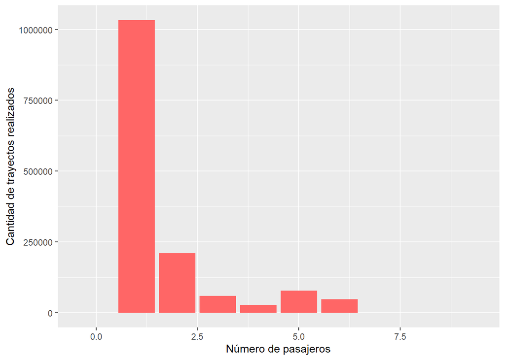

```r
train %>%
  ggplot(aes(passenger_count)) +
  geom_bar(fill = "#FF6666") +
  labs(x = "Número de pasajeros", y = "Cantidad de trayectos realizados")
```

Ahora analizaremos la variable `store_and_fwd_flag`.

La mayoría de los registros disponen de valor *N*, por tanto lo más probable es que esta columna sea eliminada ya que no aporta información al problema.

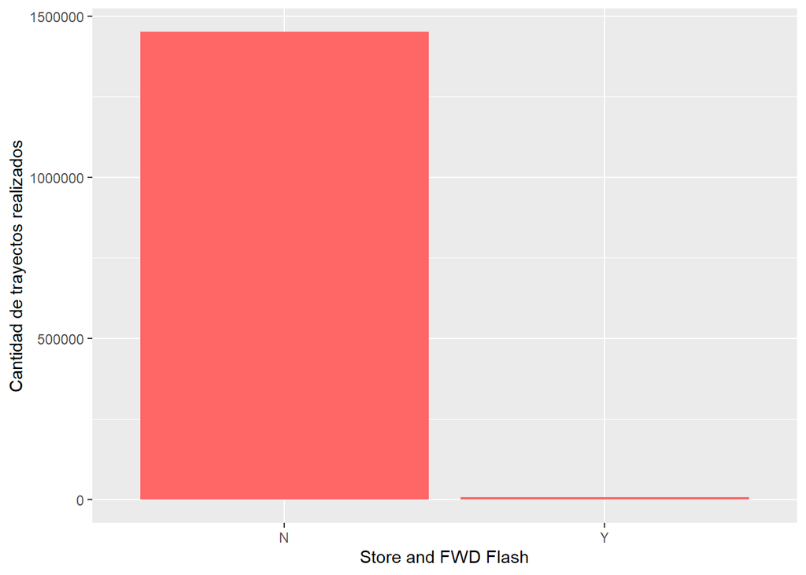

```r
train %>%
    ggplot(aes(store_and_fwd_flag)) +
    geom_bar(fill = "#FF6666") +
    labs(x = "Store and FWD Flash", y = "Cantidad de trayectos realizados")
```

En cuanto a las fechas y horas disponibles en nuestro dataset, vamos a trabajar solo sobre `pickup_time` ya que es la que aporta mayor información al problema.

Vamos a observaremos la distribución de los trayectos respecto a los meses, las horas y los días de la semana.

Nos podemos dar cuenta que nuestro dataset únicamente contiene viajes realizados entre enero y junio.

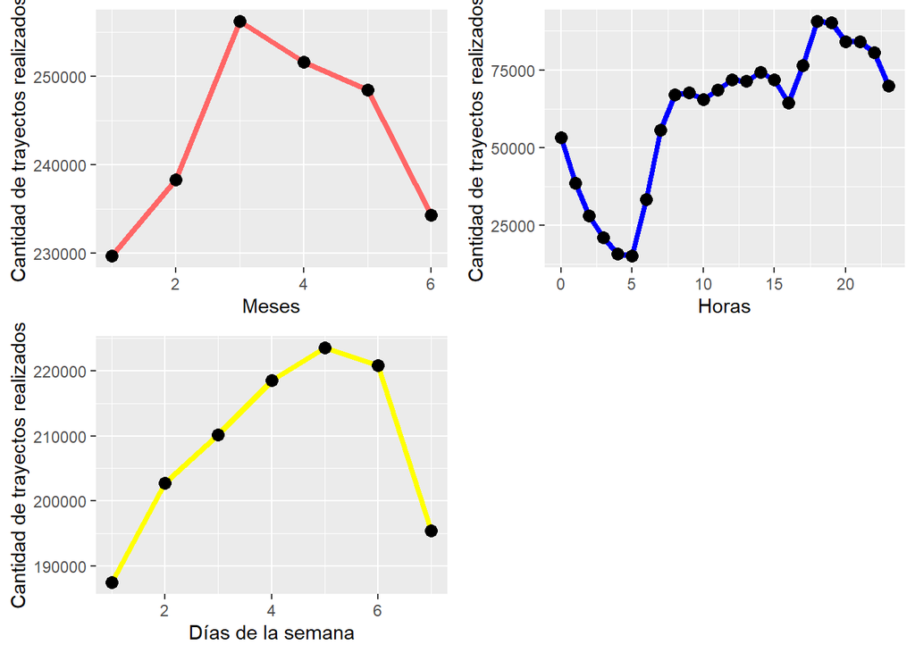

```r
count_month <- train %>%
  mutate(month_pick = month(pickup_datetime)) %>%
  group_by(month_pick) %>%
  count() %>%
  ggplot(aes(month_pick, n)) +
  geom_line(size = 1.5, color = "#FF6666") +
  geom_point(size = 3) +
  labs(x = "Meses", y = "Cantidad de trayectos realizados")
count_hour <- train %>%
  mutate(hour_pick = hour(pickup_datetime)) %>%
  group_by(hour_pick) %>%
  count() %>%
  ggplot(aes(hour_pick, n)) +
  geom_line(size = 1.5, color = "blue") +
  geom_point(size = 3) +
  labs(x = "Horas", y = "Cantidad de trayectos realizados")

count_wday <- train %>%
  mutate(week_day = wday(pickup_datetime, week_start = 1)) %>%
  group_by(week_day) %>%
  count() %>%
  ggplot(aes(week_day, n)) +
  geom_line(size = 1.5, color = "yellow") +
  geom_point(size = 3) +
  labs(x = "Días de la semana", y = "Cantidad de trayectos realizados")

suppressWarnings(grid.arrange(count_month, count_hour, count_wday, nrow = 2, ncol = 2))
```

```r
rm(count_month, count_hour, count_wday)
```

Continuando con la columna `pickup_datetime`. Se va a analizar cómo evoluciona la cantidad de trayectos cada mes según las horas y los días de la semana.

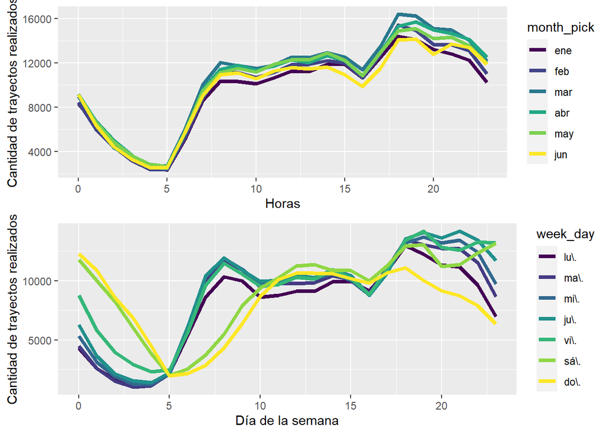

```r
month_hour <- train %>%
  mutate(hour_pick = hour(pickup_datetime),
         month_pick = factor(month(pickup_datetime, label = TRUE))) %>%
  group_by(hour_pick, month_pick) %>%
  count() %>%
  ggplot(aes(hour_pick, n, color = month_pick)) +
  geom_line(size = 1.5) +
  labs(x = "Horas", y = "Cantidad de trayectos realizados")

hour_wday <- train %>%
  mutate(hour_pick = hour(pickup_datetime),
         week_day = factor(wday(pickup_datetime, label = TRUE, week_start = 1))) %>%
  group_by(hour_pick, week_day) %>%
  count() %>%
  ggplot(aes(hour_pick, n, color = week_day)) +
  geom_line(size = 1.5) +
  labs(x = "Día de la semana", y = "Cantidad de trayectos realizados")

grid.arrange(month_hour, hour_wday, nrow = 2)
```

```r
rm(month_hour, hour_wday)
```

Un campo importante a la hora de visualizar es la distancia que existe entre el punto de recogida y destino.

Vamos a crear dos nuevas columnas que contengan esta información. Crearemos una con la distancia euclídea y otra con la manhattan, y compararemos los resultados.

Los resultados de ambas distancias calculadas serán expresadas en metros.

```r
degree_to_meters <- 111320
euclidean <- function(x1, x2, y1, y2) sqrt((x1 - y1)^2 + (x2 - y2)^2)*degree_to_meters
manhattan <- function(x1, x2, y1, y2){
    dist <- (abs(x1-y1) + abs(x2-y2)) * degree_to_meters
    return(dist)
}

train <- train %>% mutate(distance_euclidean = euclidean(pickup_latitude, pickup_longitude, dropoff_latitude, dropoff_longitude),
                                          distance_manhattan = manhattan(pickup_latitude, pickup_longitude, dropoff_latitude, dropoff_longitude))


head(train, 5)
```

|  | id | vendor_id | pickup_datetime | dropoff_datetime | passenger_count | pickup_longitude | pickup_latitude | dropoff_longitude | dropoff_latitude | store_and_fwd_flag | trip_duration | distance_euclidean | distance_manhattan |
| --- | --- | --- | --- | --- | --- | --- | --- | --- | --- | --- | --- | --- | --- |
| 1 | id2875421 | 2 | 2016-03-14 17:24:55 | 2016-03-14 17:32:30 | 1 | -73.98215 | 40.76794 | -73.96463 | 40.76560 | N | 455 | 1968.086 | 2210.739 |
| 2 | id2377394 | 1 | 2016-06-12 00:43:35 | 2016-06-12 00:54:38 | 1 | -73.98042 | 40.73856 | -73.99948 | 40.73115 | N | 663 | 2277.151 | 2947.510 |
| 3 | id3858529 | 2 | 2016-01-19 11:35:24 | 2016-01-19 12:10:48 | 1 | -73.97903 | 40.76394 | -74.00533 | 40.71009 | N | 2124 | 6671.831 | 8923.215 |
| 4 | id3504673 | 2 | 2016-04-06 19:32:31 | 2016-04-06 19:39:40 | 1 | -74.01004 | 40.71997 | -74.01227 | 40.70672 | N | 429 | 1495.941 | 1723.238 |
| 5 | id2181028 | 2 | 2016-03-26 13:30:55 | 2016-03-26 13:38:10 | 1 | -73.97305 | 40.79321 | -73.97292 | 40.78252 | N | 435 | 1189.963 | 1204.313 |

Si visualizamos ambas, podemos ver que son muy similares, algo de esperar.

Podemos apreciar que la mayoría de los trayectos tienen una distancia similar, aunque existen 2 puntos donde esta tendencia cambia.

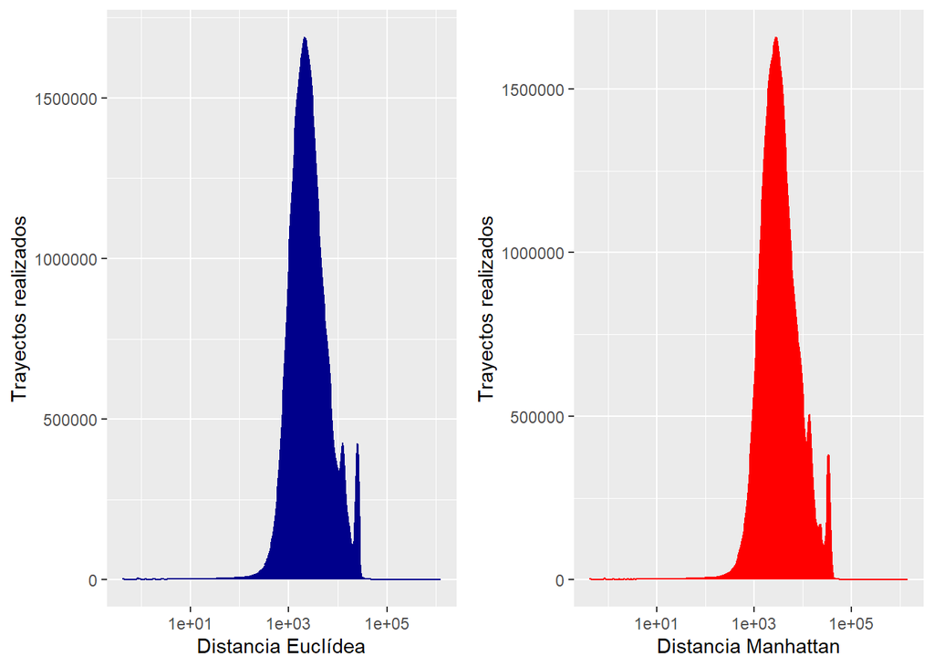

```r
distancia1 <- train %>%
  ggplot(aes(distance_euclidean)) +
  geom_density(aes(y=after_stat(count)), color="darkblue", fill="darkblue") +
  scale_x_log10() +
  labs(x = "Distancia Euclídea", y = "Trayectos realizados")

distancia2 <- train %>%
  ggplot(aes(distance_manhattan)) +
  geom_density(aes(y=after_stat(count)), color="red", fill="red") +
  scale_x_log10() +
  labs(x = "Distancia Manhattan", y = "Trayectos realizados")

suppressWarnings(grid.arrange(distancia1, distancia2, nrow=1))
```

```r
rm(degree_to_meters, distancia1, distancia2)
```

Tras la visualización de las coordenadas de las sitios de recogida podemos observer la siguiente gráfica.

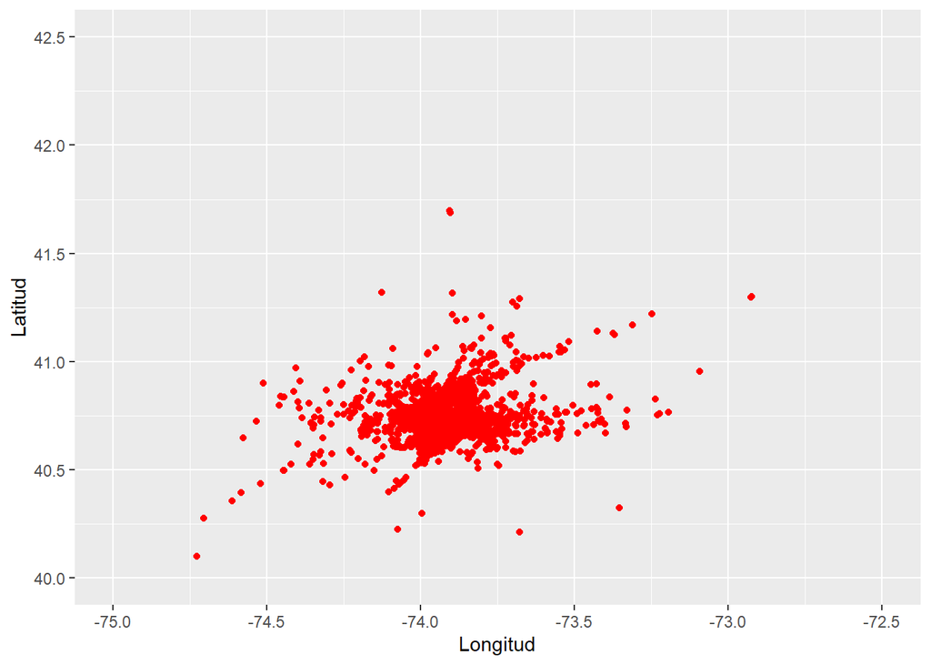

```r
train %>%
  ggplot(aes(pickup_longitude, pickup_latitude)) +
  geom_point(color='red') +
  xlim(-75, -72.5) +
  ylim(40, 42.5) +
  labs(x = "Longitud", y = "Latitud")
```

Para finalizar este punto, vamos a ver información sobre nuestra columna objetivo del aprendizaje supervisado, `trip_duration`.

Empezaremos viendo la distribución de las duraciones de los trayectos.

Como se puede observar el resultado es muy simular a una campana de Gauss.

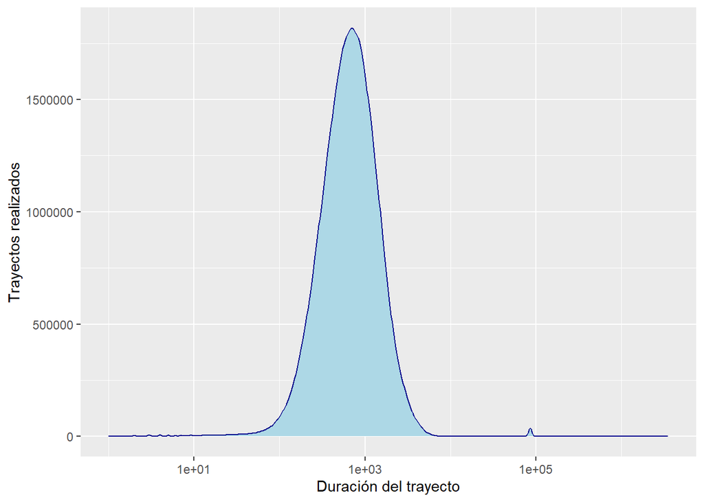

```r
train %>%
  ggplot(aes(trip_duration)) +
  geom_density(aes(y=after_stat(count)), color="darkblue", fill="lightblue") +
  scale_x_log10() +
  labs(x = "Duración del trayecto", y = "Trayectos realizados")
```

Ahora analizaremos la media y la mediana de la duración de los viajes, diferenciando por vendor/taxista.

Se puede observar que la mediana de ambos es muy similar.

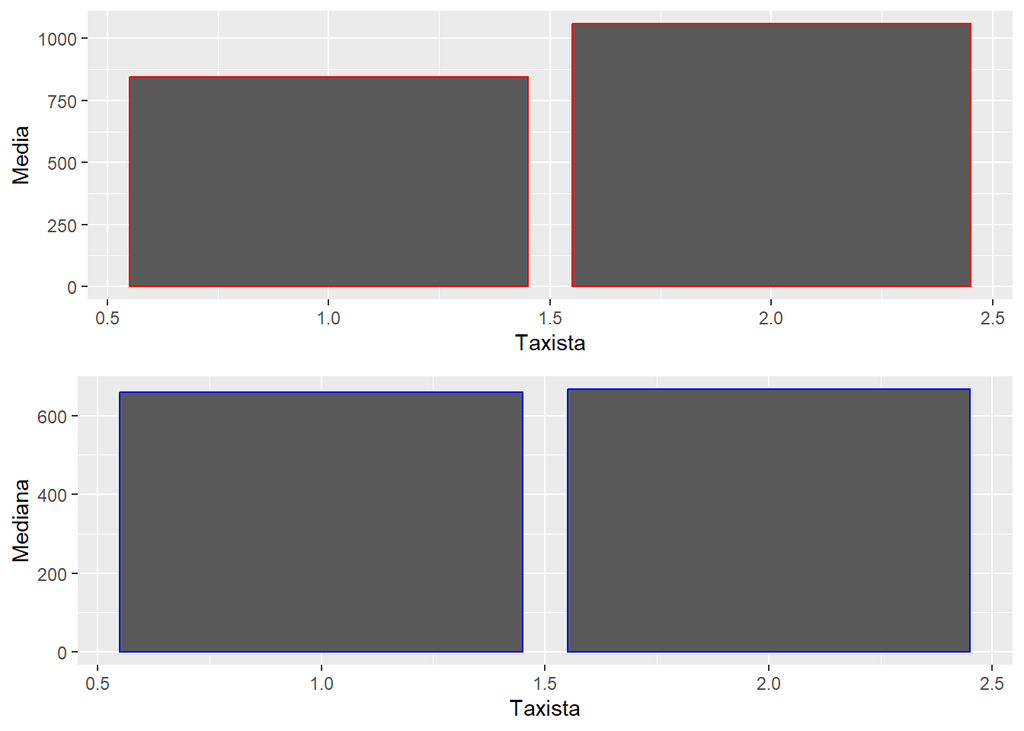

```r
dur_vendor_1 <- train %>%
  group_by(vendor_id) %>%
  summarise(mean_duration = mean(trip_duration)) %>%
  ggplot(aes(x=vendor_id, y=mean_duration)) +
  geom_col(position="dodge", color='red') +
  labs(x = "Taxista", y = "Media")

dur_vendor_2 <- train %>%
  group_by(vendor_id) %>%
  summarise(median_duration = median(trip_duration)) %>%
  ggplot(aes(x=vendor_id, y=median_duration)) +
  geom_col(position="dodge", color='blue') +
  labs(x = "Taxista", y = "Mediana")

grid.arrange(dur_vendor_1, dur_vendor_2, ncol=1)
```

```r
rm(dur_vendor_1, dur_vendor_2)
```

La primera gráfica nos muestra un número muy alto de duración de los viajes cuando el número de pasajeros es 0, y muy bajo cuando es 7, 8 y 9.

Si miramos la siguiente tabla, podemos ver que justamente esos casos disponen de muy pocos registros en el dataset y por tanto se pueden considerar como datos no válidos (posiblemente sean errores).

Si ignoramos esa columna vemos que la duración de los trayectos respecto a la cantidad de pasajeros son parecidas.

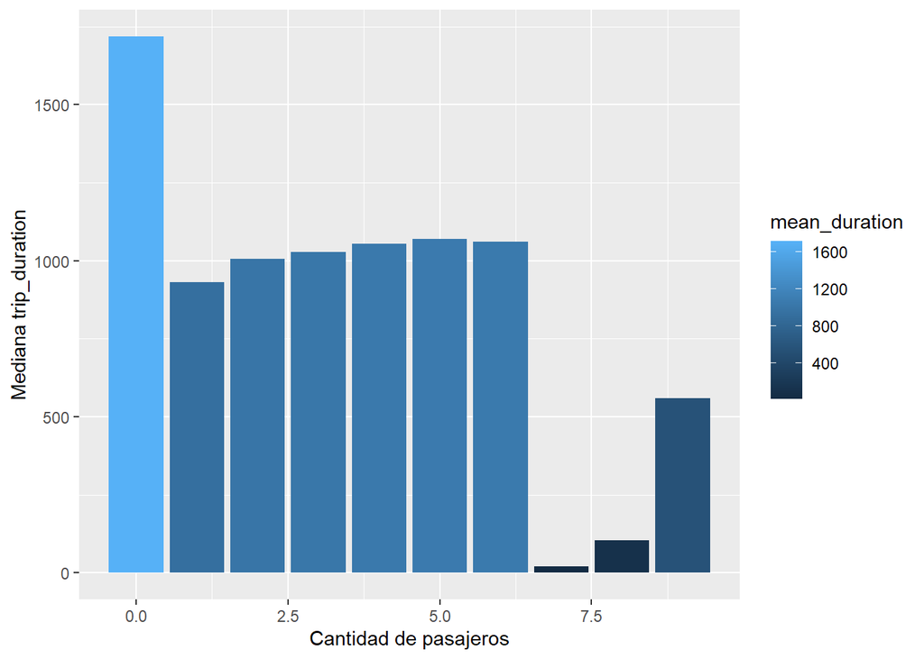

```r
train %>%
  group_by(passenger_count) %>%
  summarise(mean_duration = mean(trip_duration)) %>%
  ggplot(aes(x=passenger_count, y=mean_duration, fill=mean_duration)) +
  geom_col(position="dodge") +
  labs(x = "Cantidad de pasajeros", y = "Mediana trip_duration")
```

```r
train %>%
  group_by(passenger_count) %>%
  count()
```

| passenger_count | n |
| --- | --- |
| 0 | 60 |
| 1 | 1033540 |
| 2 | 210318 |
| 3 | 59896 |
| 4 | 28404 |
| 5 | 78088 |
| 6 | 48333 |
| 7 | 3 |
| 8 | 1 |
| 9 | 1 |

Continuamos con `pickup_datetime`. Vamos a ver como evoluciona la duración de los viajes según los meses, las horas, y los días de la semana.

Aunque se observen picos, la diferencia entre los valores es mínima.

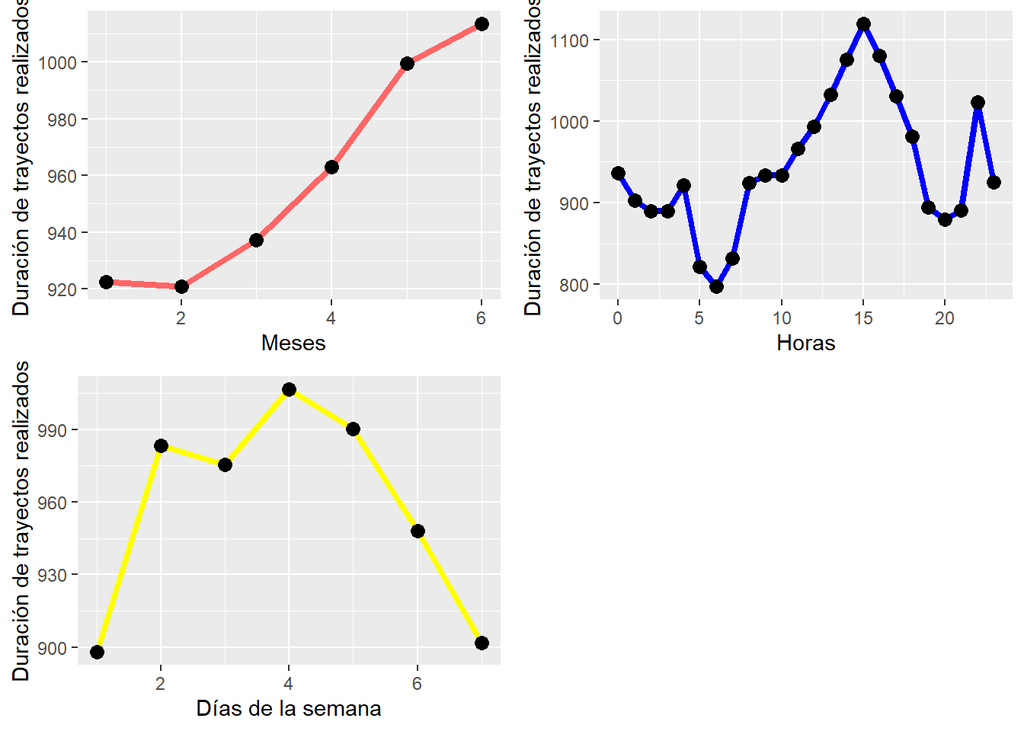

```r
dur_month <- train %>%
  mutate(month_pick = month(pickup_datetime)) %>%
  group_by(month_pick) %>%
  summarise(mean_duration = mean(trip_duration)) %>%
  ggplot(aes(month_pick, mean_duration)) +
  geom_line(size = 1.5, color = "#FF6666") +
  geom_point(size = 3) +
  labs(x = "Meses", y = "Duración de trayectos realizados")

dur_hour <- train %>%
  mutate(hour_pick = hour(pickup_datetime)) %>%
  group_by(hour_pick) %>%
  summarise(mean_duration = mean(trip_duration)) %>%
  ggplot(aes(hour_pick, mean_duration)) +
  geom_line(size = 1.5, color = "blue") +
  geom_point(size = 3) +
  labs(x = "Horas", y = "Duración de trayectos realizados")

dur_wday <- train %>%
  mutate(week_day = wday(pickup_datetime, week_start = 1)) %>%
  group_by(week_day) %>%
  summarise(mean_duration = mean(trip_duration)) %>%
  ggplot(aes(week_day, mean_duration)) +
  geom_line(size = 1.5, color = "yellow") +
  geom_point(size = 3) +
  labs(x = "Días de la semana", y = "Duración de trayectos realizados")

grid.arrange(dur_month, dur_hour, dur_wday, ncol = 2)
```

```r
rm(dur_month, dur_hour, dur_wday)
```

Para concluir este apartado, se va a indicar la distribución de las distancias respecto a la duración de los trayectos.

Como se puede observar, ambas distancias generan una gráfica muy simular.

Por tanto, no podemos decidir a simple vista que distancia mejorarán los resultados de nuestra predicción en el aprendizaje supervisado.

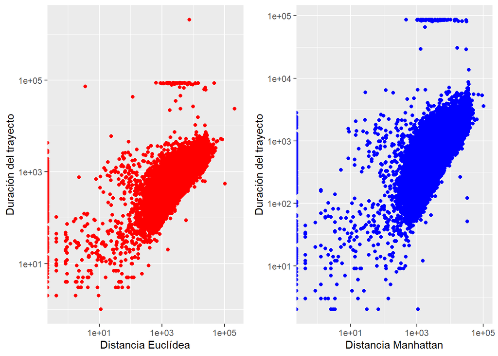

```r
set.seed(2)
dist_dur_1 <- train %>%
  sample_n(5e4) %>%
  ggplot(aes(distance_euclidean, trip_duration)) +
  geom_point(color='red') +
  scale_x_log10() +
  scale_y_log10() +
  labs(x = "Distancia Euclídea", y = "Duración del trayecto")

dist_dur_2 <- train %>%
  sample_n(5e4) %>%
  ggplot(aes(distance_manhattan, trip_duration)) +
  geom_point(color='blue') +
  scale_x_log10() +
  scale_y_log10() +
  labs(x = "Distancia Manhattan", y = "Duración del trayecto")

grid.arrange(dist_dur_1, dist_dur_2, ncol=2)
```

```r
rm(dist_dur_1, dist_dur_2)
```

# Supervisado

## Preprocesamiento

Tras haber visualizado los datos podemos hacernos una idea de que datos debemos modificar/ajustar en nuestro dataset.

Aun así, comenzaremos viendo un resumen del dataset.

```r
summary(train)
```

```
##       id              vendor_id     pickup_datetime    dropoff_datetime
##  Length:1458644     Min.   :1.000   Length:1458644     Length:1458644
##  Class :character   1st Qu.:1.000   Class :character   Class :character
##  Mode  :character   Median :2.000   Mode  :character   Mode  :character
##                     Mean   :1.535
##                     3rd Qu.:2.000
##                     Max.   :2.000
##  passenger_count pickup_longitude  pickup_latitude dropoff_longitude
##  Min.   :0.000   Min.   :-121.93   Min.   :34.36   Min.   :-121.93
##  1st Qu.:1.000   1st Qu.: -73.99   1st Qu.:40.74   1st Qu.: -73.99
##  Median :1.000   Median : -73.98   Median :40.75   Median : -73.98
##  Mean   :1.665   Mean   : -73.97   Mean   :40.75   Mean   : -73.97
##  3rd Qu.:2.000   3rd Qu.: -73.97   3rd Qu.:40.77   3rd Qu.: -73.96
##  Max.   :9.000   Max.   : -61.34   Max.   :51.88   Max.   : -61.34
##  dropoff_latitude store_and_fwd_flag trip_duration     distance_euclidean
##  Min.   :32.18    Length:1458644     Min.   :      1   Min.   :      0
##  1st Qu.:40.74    Class :character   1st Qu.:    397   1st Qu.:   1401
##  Median :40.75    Mode  :character   Median :    662   Median :   2362
##  Mean   :40.75                       Mean   :    959   Mean   :   3950
##  3rd Qu.:40.77                       3rd Qu.:   1075   3rd Qu.:   4276
##  Max.   :43.92                       Max.   :3526282   Max.   :1245961
##  distance_manhattan
##  Min.   :      0
##  1st Qu.:   1791
##  Median :   3048
##  Mean   :   5110
##  3rd Qu.:   5619
##  Max.   :1436889
```

Podemos observar que nuestro dataset no dispone de ningún dato nulo.

Procederemos a eliminar la columna id, esta es generada aleatoriamente por lo que no aporta información.

```r
train <- select(train, -id)
```

La columna `vendor_id` se encuentra en formato númerico y por lo que hemos visto en el apartado anterior puede ser importante a la hora de predecir.

La columna `dropoff_datetime` no aporta una información relevante al problema ya que es la suma de `pickup_datetime` y `trip_duration`.

Procedemos a borrarla

```r
train <- train %>% select(-dropoff_datetime)
```

Sin embargo, la columna `pickup_datetime` si es importante, pero es necesario que realicemos un procesamiento ya que está en formato fecha.

Vamos a dividir la columna en 3, mes, hora y día de la semana.

```r
train <- train %>% mutate(month = month(pickup_datetime))
train <- train %>% mutate(hour = hour(pickup_datetime))
train <- train %>% mutate(week_day = wday(pickup_datetime, week_start = 1))

train <- train %>% select(-pickup_datetime)
```

La columna `passenger_count` se encuentra en formato númerico. Tal y como visualizamos en el anterior punto existían valores “*raros*” en esta columna.

Vamos a eliminar todos los registros con `passenger_count` igual a 0, 7, 8 y 9.

```r
train <- train %>% filter(passenger_count != 0 & passenger_count != 7 & passenger_count != 8 & passenger_count != 9)
```

Las columnas `pickup_*` y `dropoff_*` continen las coordenadas. En el apartado anterior de visualización creamos dos columnas nuevas para mostrar la distancia entre el lugar de recogida y el destino.

Estas dos columnas no van a ser utilizas, por lo que procedemos a borrarlas.

```r
train <- train %>% select(-pickup_latitude)
train <- train %>% select(-pickup_longitude)
train <- train %>% select(-dropoff_latitude)
train <- train %>% select(-dropoff_longitude)
```

Sin embargo, las dos columnas que creamos anteriormente presentan registros con distancias igual a 0. Estas deben tratarse de errores, por lo que procedemos con su eliminación.

```r
train <- train %>% filter(distance_euclidean != 0 & distance_manhattan != 0)
```

Continuando con la última variable. Como hemos podido observar tanto en la visualización como con la función summary, la columna `store_and_fwd_flag` dispone de muy pocos valores de tipo Y, y por tanto no nos aporta información.

Procedemos a borrarla.

```r
train <- train %>% select(-store_and_fwd_flag)
```

Para finalizar este apartado, se realizará un normalizado las columnas para que tengan un valor comprendido entre 0 y 1.

```r
range_model <- preProcess(train, method = "range")
train <- predict(range_model, newdata = train)
rm(range_model)
```

## Predicción

El objetivo de la predicción en este dataset de taxis es predecir la duración de un viaje en función de todas las variables disponibles.

### División del conjunto

El primer paso es eliminar valores de nuestro dataset, ya que debido a la cantidad de registros no es posible su computación.

```r
set.seed(123)
ind <- createDataPartition(train$trip_duration, p = 0.001, list = FALSE)
train <- train[ind,]
rm(ind)
```

Ahora dividiremos nuestro conjunto en *train* y *test*.

```r
set.seed(456)
ind <- createDataPartition(train$trip_duration, p = 0.7, list = FALSE)
training_set <- train[ind,]
test_set <- train[-ind,]
rm(ind)
```

### Importancia de las variables

Vamos a realizar un entrenamiento mediante *Random Forest* para observar cuales son las variables más importantes en nuestro dataset.

Este modelo creado también será usado posteriormente para realizar predicciones.

Se observa que las distancias son las más importantes, superando la euclídea a la manhattan.

No vamos a eliminar ninguna de estas variables del dataset ya que vamos a ir probando como se comportan los modelos con su eliminación.

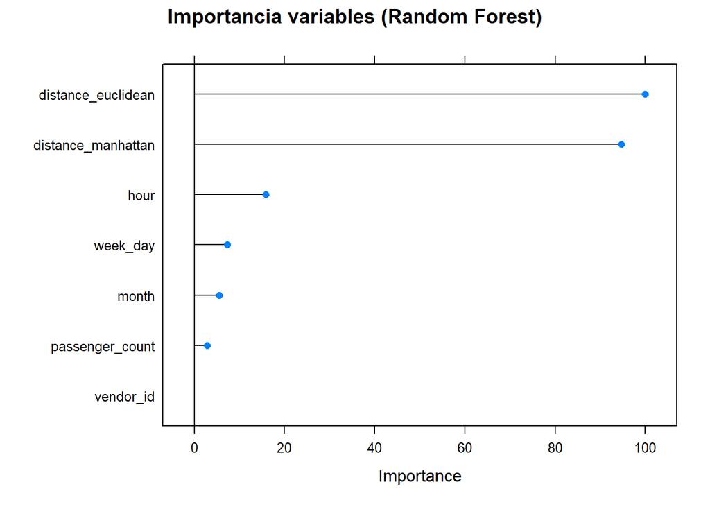

```r
model_rf <- train(trip_duration ~ ., data = training_set, method = "rf")
imp <- varImp(model_rf)
plot(imp, main = "Importancia variables (Random Forest)")
```

## Entrenamiento

Empezaremos utilizando regresión lineal.

```r
# Dividir conjunto de train y test en dos, uno con cada distancia.

training_set_euclidean <- select(training_set, -distance_manhattan)
training_set_manhattan <- select(training_set, -distance_euclidean)

test_set_euclidean <- select(test_set, -distance_manhattan)
test_set_manhattan <- select(test_set, -distance_euclidean)
```

Ahora, entrenamos el modelo con ambos datos de train:

```r
model_lm_euclidean <- train(trip_duration ~ .,
                            data = training_set_euclidean,
                            method = "lm")
predicted_lm_euclidean <- predict(model_lm_euclidean,
                                  select(test_set_euclidean, -trip_duration))

postResample(predicted_lm_euclidean, test_set_euclidean$trip_duration)
```

```
##         RMSE     Rsquared          MAE
## 0.0001128188 0.5936826823 0.0000828220
```

```r
model_lm_manhattan <- train(trip_duration ~ .,
                            data = training_set_manhattan,
                            method = "lm")
predicted_lm_manhattan <- predict(model_lm_manhattan,
                                  select(test_set_manhattan, -trip_duration))

postResample(predicted_lm_manhattan, test_set_manhattan$trip_duration)
```

```
##         RMSE     Rsquared          MAE
## 0.0001127156 0.5929620046 0.0000825294
```

```r
resam <- resamples(list(EUC = model_lm_euclidean,
                        MAN = model_lm_manhattan))
summary(resam)
```

```
##
## Call:
## summary.resamples(object = resam)
##
## Models: EUC, MAN
## Number of resamples: 25
##
## MAE
##             Min.      1st Qu.       Median         Mean      3rd Qu.
## EUC 7.470956e-05 7.934337e-05 8.173332e-05 8.183042e-05 8.430475e-05
## MAN 7.751571e-05 8.091833e-05 8.244996e-05 8.268354e-05 8.392152e-05
##             Max. NA's
## EUC 8.893851e-05    0
## MAN 9.077866e-05    0
##
## RMSE
##             Min.      1st Qu.       Median         Mean      3rd Qu.
## EUC 9.908712e-05 0.0001131512 0.0001202717 0.0001203689 0.0001312543
## MAN 1.090085e-04 0.0001145401 0.0001225887 0.0001221160 0.0001269971
##             Max. NA's
## EUC 0.0001383157    0
## MAN 0.0001435306    0
##
## Rsquared
##          Min.   1st Qu.    Median      Mean   3rd Qu.      Max. NA's
## EUC 0.5414675 0.5949269 0.6294260 0.6225607 0.6446965 0.7064989    0
## MAN 0.5158429 0.5884741 0.6139354 0.6133371 0.6589657 0.6885963    0
```

Se puede observar que ambos dan resultados muy parecidos, aun así la distancia euclídea da mejores resultados que la manhattan.

Vamos a volver a entrenar ambos modelos pero ahora realizando ajuste en los hiperparámetros:

```r
lm_ctrl <- trainControl(
  method = "repeatedcv",
  number = 5,
  repeats = 5,
  search = "random"
)

model_lm_euclidean_ctrl <- train(trip_duration ~ .,
                            data = training_set_euclidean,
                            method = "lm",
                            trControl = lm_ctrl,
                            tuneLength = 10)

predicted_lm_euclidean_ctrl <- predict(model_lm_euclidean,
                                  select(test_set_euclidean, -trip_duration))

postResample(predicted_lm_euclidean_ctrl, test_set_euclidean$trip_duration)
```

```
##         RMSE     Rsquared          MAE
## 0.0001128188 0.5936826823 0.0000828220
```

```r
model_lm_manhattan_ctrl <- train(trip_duration ~ .,
                            data = training_set_manhattan,
                            method = "lm",
                            trControl = lm_ctrl,
                            tuneLength = 10)

predicted_lm_manhattan_ctrl <- predict(model_lm_manhattan,
                                  select(test_set_manhattan, -trip_duration))

postResample(predicted_lm_manhattan_ctrl, test_set_manhattan$trip_duration)
```

```
##         RMSE     Rsquared          MAE
## 0.0001127156 0.5929620046 0.0000825294
```

```r
resam <- resamples(list(EUC = model_lm_euclidean_ctrl,
                        MAN = model_lm_manhattan_ctrl))
summary(resam)
```

```
##
## Call:
## summary.resamples(object = resam)
##
## Models: EUC, MAN
## Number of resamples: 25
##
## MAE
##             Min.      1st Qu.       Median         Mean      3rd Qu.
## EUC 7.270360e-05 7.802745e-05 8.044021e-05 8.115232e-05 8.560012e-05
## MAN 6.970988e-05 7.891683e-05 8.269996e-05 8.220356e-05 8.556611e-05
##             Max. NA's
## EUC 9.128758e-05    0
## MAN 9.092459e-05    0
##
## RMSE
##             Min.      1st Qu.       Median         Mean      3rd Qu.
## EUC 9.443334e-05 0.0001081502 0.0001171875 0.0001171842 0.0001276460
## MAN 9.444028e-05 0.0001051338 0.0001202042 0.0001189592 0.0001302339
##            Max. NA's
## EUC 0.000138404    0
## MAN 0.000152033    0
##
## Rsquared
##          Min.   1st Qu.    Median      Mean   3rd Qu.      Max. NA's
## EUC 0.5354619 0.5739745 0.6143498 0.6206134 0.6779628 0.6950297    0
## MAN 0.3758607 0.5472309 0.6237546 0.6090115 0.6766204 0.7409798    0
```

Procedemos a entrenar el modelo utilizando XGBoost

```r
training_set_factor <- map_df(training_set, function(columna) {
  columna %>%
    as.factor() %>%
    as.numeric %>%
    { . - 1 }
})

test_set_factor <- map_df(test_set, function(columna) {
  columna %>%
    as.factor() %>%
    as.numeric %>%
    { . - 1 }
})

train_matrix <-
  training_set_factor %>%
  select(-trip_duration) %>%
  as.matrix() %>%
  xgb.DMatrix(data = ., label = training_set_factor$trip_duration)

test_matrix <-
  test_set_factor %>%
  select(-trip_duration) %>%
  as.matrix() %>%
  xgb.DMatrix(data = ., label = test_set_factor$trip_duration)

param <- list(
      booster = "gbtree",
      objective="reg:linear",
      eval_metric = "rmse",
      max_depth = 4,
      eta = 0.3,
      subsample = 0.8,
      colsample_bytree = 0.8
      )

set.seed(123)
model_xgb <- xgboost(data = train_matrix,
                     nrounds = 10,
                     params = param,
                     nthread = 2)
```

```
## [20:10:43] WARNING: amalgamation/../src/objective/regression_obj.cu:203: reg:linear is now deprecated in favor of reg:squarederror.
```

```r
predict_xgb <- predict(model_xgb, test_matrix)
postResample(predict_xgb, test_set_factor$trip_duration)
```

```
##       RMSE   Rsquared        MAE
## 76.0376857  0.5258062 60.9132809
```

Se puede observar que los resultados obtenidos son peores que con la regresión lineal.

Después de varias pruebas ajustando los hiperparámetros, y utilizando validación cruzada, esos hiperparámetros son los que mejor resultado aportan.

Para terminar con este modelo, vamos a mostrar una gráfica sobre la importancia que han tenido las distintas variables.

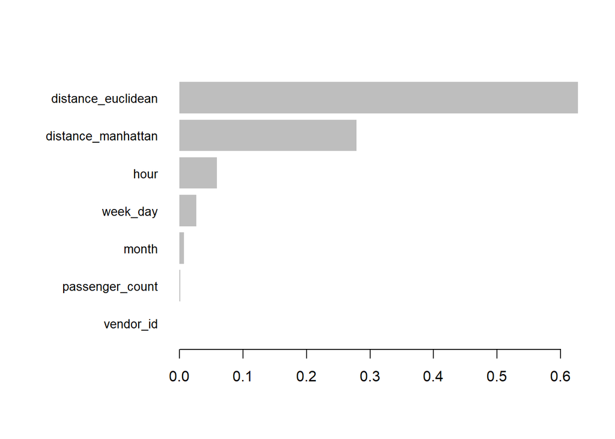

```r
xgb_imp_freq <- xgb.importance(feature_names = colnames(train_matrix),
                               model = model_xgb)
xgb.plot.importance(xgb_imp_freq)
```

En puntos anteriores entrenamos un random forest para determinar la importancia de las variables.

Vamos a observar que resultados aporta:

```r
predicted_rf <- predict(model_rf,
                          select(test_set, -trip_duration))

postResample(predicted_rf, test_set$trip_duration)
```

```
##         RMSE     Rsquared          MAE
## 1.010730e-04 6.767166e-01 7.108522e-05
```

Después de analizar los distintos modelos, se llega a la conclusión de que el mejor modelo para este conjunto de datos es **Random Forest**.

# No supervisado

## Preprocesamiento

La fase de preprocesamiento implica la modificación y limpieza de datos para que puedan ser utilizados posteriormente para la clasificación mediante técnicas de clustering.

### Cálculo de distancia

Se añade una columna en el dataset que represente la distancia entre el punto de recogida y el de llegada. Para ello, se usará la función de distancia Harvesine, una fórmula matemática utilizada para calcular la distancia en una superficie esférica (en este caso de la tierra) entre dos puntos geográficos (punto de recogida y punto de llegada). Estos datos vienen dados en metros.

Se ha decidido usar esta distancia porque mide distancias rectilíneas de forma similar a la euclídea (al menos para una superficie esférica como es el planeta Tierra), y esta distancia supuso la variable más importante en el apartado “*Preprocesamiento supervisado*”.

```r
# eliminación de variables usadas en supervisado
rm(list = ls())

# recarga de datos
train <- read.csv("datos/train.csv")

# calcular distancia Harversine
train <- train %>%
  mutate(distance = distHaversine(cbind(longitude = pickup_longitude, latitude = pickup_latitude), cbind(longitude = dropoff_longitude, latitude = dropoff_latitude)))

# representa las caracterícticas de distancia
summary(train$distance)
```

```
##    Min. 1st Qu.  Median    Mean 3rd Qu.    Max.
##       0    1233    2096    3445    3880 1242299
```

### Eliminación de datos

Dado que el conjunto de datos es grande y existen columnas redundantes, se va a eliminar aquellas no relevantes para simplificar y mejorar la eficiencia del análisis.

```r
# eliminación columnas no relevantes
train$id <- NULL
train$vendor_id <- NULL
train$passenger_count <- NULL
train$pickup_datetime <- NULL
train$dropoff_datetime <- NULL
train$store_and_fwd_flag <- NULL
train$pickup_longitude <- NULL
train$pickup_latitude <- NULL
train$dropoff_longitude <- NULL
train$dropoff_latitude <- NULL

# se representan el dataset train
head(train)
```

|  | trip_duration | distance |
| --- | --- | --- |
| 1 | 455 | 1500.199 |
| 2 | 663 | 1807.530 |
| 3 | 2124 | 6392.251 |
| 4 | 429 | 1487.163 |
| 5 | 435 | 1189.920 |
| 6 | 443 | 1100.174 |

### Datos imperfectos

A continuación, se va a representar la distancia frente a la duración para visualizar si existen datos imperfectos.

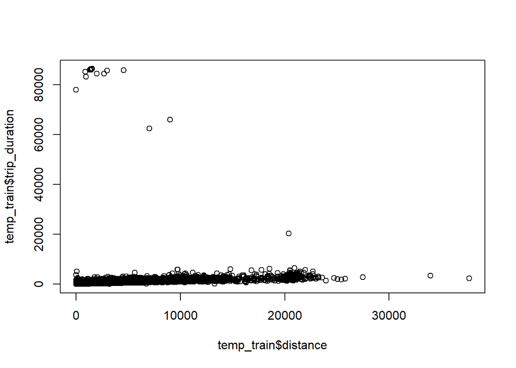

```r
# REPRESENTACIÓN TODO DATASET -> tarda en cargar
# plot(x = train$distance, y = train$trip_duration)

# REPRESENTACIÓN ALEATORIA
temp_train <- sample_n(train, 10000)
plot(x = temp_train$distance, y = temp_train$trip_duration)
```

```r
rm(temp_train)
```

Por esta razón, se va a acotar tanto la duración como la distancia en unas cotas que representen gran parte del conjunto de los datos.

Para la **duración**, se va a probar manualmente a acotar la duración con un intervalo máximo y mínimo. En este caso, se ha probado con el intervalo [10, 10.000] segundos, descartando solamente un 0.29% del total de los datos.

```r
# ACOTAR DURACIÓN

summary(train$trip_duration)
```

```
##    Min. 1st Qu.  Median    Mean 3rd Qu.    Max.
##       1     397     662     959    1075 3526282
```

```r
# acotamos duración máxima
max_dur <- 10000
lim_max_dur <- nrow(train %>% filter(trip_duration >= max_dur))
sprintf("Límitando como máximo la duración a %ss -> eliminación %s elementos (%s%% del total)", max_dur, lim_max_dur, 100 * lim_max_dur / nrow(train))
```

```
## [1] "Límitando como máximo la duración a 10000s -> eliminación 2123 elementos (0.145546137371422% del total)"
```

```r
# acotamos duración mínima
min_dur <- 10
lim_min_dur <- nrow(train %>% filter(trip_duration <= min_dur))
sprintf("Límitando como mínimo la duración a %ss -> eliminación %s elementos (%s%% del total)", min_dur, lim_min_dur, 100 * lim_min_dur / nrow(train))
```

```
## [1] "Límitando como mínimo la duración a 10s -> eliminación 2166 elementos (0.148494080803815% del total)"
```

```r
# aplicando ambas restricciones
lim_dur <- nrow(train %>% filter(trip_duration <= min_dur | trip_duration >= max_dur)) # nolint
sprintf("Límitando duración entre [%s, %s] -> eliminación %s elementos (%s%% del total)", min_dur, max_dur, lim_dur, 100 * lim_dur / nrow(train)) # nolint
```

```
## [1] "Límitando duración entre [10, 10000] -> eliminación 4289 elementos (0.294040218175237% del total)"
```

```r
# descartamos aquellos que no cumplan restricciones
train <- train %>% filter(trip_duration > min_dur & trip_duration < max_dur)
rm(max_dur, lim_max_dur, min_dur, lim_min_dur, lim_dur)
```

Para la **distancia**, se va a probar manualmente a acotar la distancia con un intervalo máximo y mínimo. En este caso, se ha probado con el intervalo [10, 25.000] metros, descartando solamente un 0.58% del total de los datos (que ya han sido previamente filtrados en la duración.

```r
# ACOTAR DISTANCIA

summary(train$distance)
```

```
##    Min. 1st Qu.  Median    Mean 3rd Qu.    Max.
##       0    1236    2099    3448    3883 1242299
```

```r
# acotamos distancia máxima
max_dist <- 25000
lim_max_dist <- nrow(train %>% filter(distance >= max_dist))
sprintf("Límitando como máximo la distancia a %sm -> eliminación %s elementos (%s%% del total)", max_dist, lim_max_dist, 100 * lim_max_dist / nrow(train))
```

```
## [1] "Límitando como máximo la distancia a 25000m -> eliminación 1399 elementos (0.0961938453816297% del total)"
```

```r
# acotamos distancia mínima
min_dist <- 10
lim_min_dist <- nrow(train %>% filter(distance <= min_dist))
sprintf("Límitando como mínimo la distancia a %sm -> eliminación %s elementos (%s%% del total)", min_dist, lim_min_dist, 100 * lim_min_dist / nrow(train))
```

```
## [1] "Límitando como mínimo la distancia a 10m -> eliminación 7108 elementos (0.488738994262061% del total)"
```

```r
# aplicando ambas restricciones
lim_dist <- nrow(train %>% filter(distance <= min_dist | distance >= max_dist))
sprintf("Límitando distancia entre [%s, %s] -> eliminación %s elementos (%s%% del total)", min_dist, max_dist, lim_dist, 100 * lim_dist / nrow(train))
```

```
## [1] "Límitando distancia entre [10, 25000] -> eliminación 8507 elementos (0.584932839643691% del total)"
```

```r
# descartamos aquellos que no cumplan restricciones
train <- train %>% filter(distance > min_dist & distance < max_dist)
rm(max_dist, lim_max_dist, min_dist, lim_min_dist, lim_dist)
```

### Normalización de los datos

Para que los datos dispongan de una distribución similar y estén en la misma escala se precisa realizar la normalización. Esta transformará tanto la duración como la distancia en un **intervalo [0, 1]**.

```r
# normalización de duración
train$trip_duration <- rescale(train$trip_duration)

# normalización de distancia
train$distance <- rescale(train$distance)

# muestra el conjunto de entrenamiento
head(train)
```

|  | trip_duration | distance |
| --- | --- | --- |
| 1 | 0.04452020 | 0.05963621 |
| 2 | 0.06537652 | 0.07193551 |
| 3 | 0.21187205 | 0.25541526 |
| 4 | 0.04191317 | 0.05911447 |
| 5 | 0.04251479 | 0.04721888 |
| 6 | 0.04331696 | 0.04362724 |

### Representación de datos

Una vez se ha aplicado las distintas técnicas de preprocesamiento al dataset, se va a representar para identificar a simple vista si existen algunos datos incongruentes.

Tras el análisis visual, se puede concretar que el dataset se encuentra preparado para su uso en Data Mining.

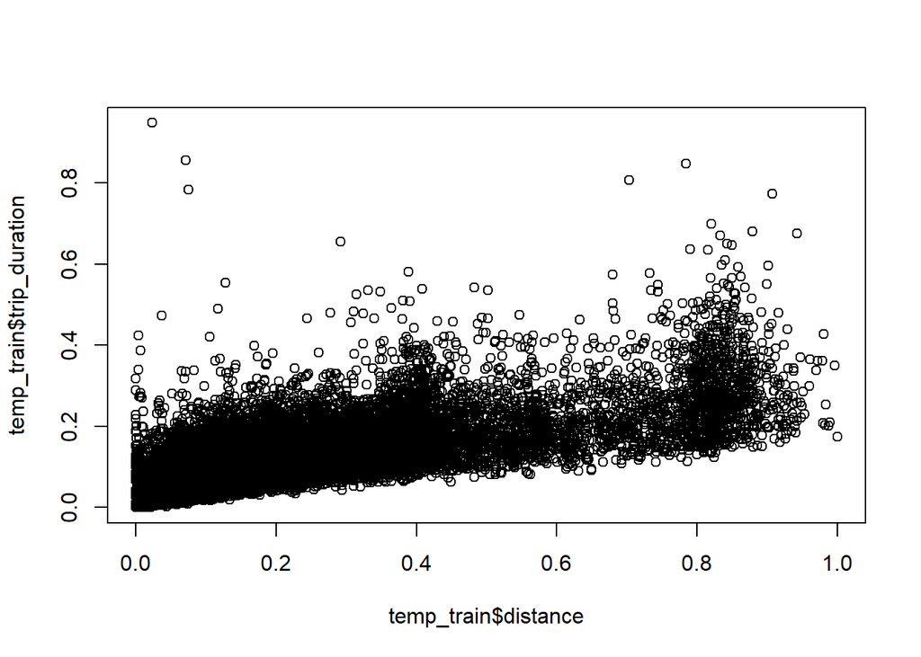

```r
# REPRESENTACIÓN TODO DATASET -> tarda en cargar
# plot(x = train$distance, y = train$trip_duration)

# REPRESENTACIÓN ALEATORIA
temp_train <- sample_n(train, 50000)
plot(x = temp_train$distance, y = temp_train$trip_duration)
```

```r
rm(temp_train)
```

## Data Mining: Clustering

Data Mining es el proceso de explorar y analizar grandes conjuntos de datos con el fin de descubrir patrones y relaciones ocultas.

Dentro de este proceso, existen las técnicas de clustering, que son aquellas que se utilizan para agrupar datos similares en “clusters”, conjuntos o grupos.

En este caso, se va a aplicar clustering para identificar los distintos tipos de trayecto en función de la distancia y de la duración.

### Clustering con K-means

1. **Obtener número óptimo de clusters**

Se representa la compactación en relación con el número de clusters.

```r
vector_compactacion <- 0
for(i in 1:15) {
  km_train_aux2 <- kmeans(train,center=i,nstar=20)
  vector_compactacion[i] <- km_train_aux2$tot.withinss
}

par(mfrow = c(1,1))
plot(1:15, vector_compactacion, type = "b",
     xlab = "Numero de clusters",
     ylab = "Compactacion")
```

[output not shown]

Se determina que el número óptimo de clusters son 3, ya que a partir de ahí se estabiliza.

2. **Aplicar función kmeans**

Se extrae los clusters mediante la técnica de k-means o k-medias.

```r
# división en clústeres
km_train <- kmeans(train, center = 3, nstar = 20)

# breve resumen resultados tras aplicar la técnica
summary(km_train)
```

```
##              Length  Class  Mode
## cluster      1445848 -none- numeric
## centers            6 -none- numeric
## totss              1 -none- numeric
## withinss           3 -none- numeric
## tot.withinss       1 -none- numeric
## betweenss          1 -none- numeric
## size               3 -none- numeric
## iter               1 -none- numeric
## ifault             1 -none- numeric
```

3. **Representación de clústeres**

Se representan los clústeres extraídos mediante k-means.

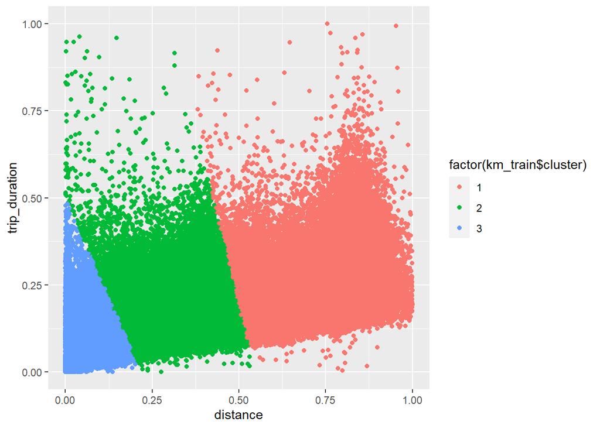

```r
# representación de los clusters
ggplot(train, aes(x = distance, y = trip_duration, color = factor(km_train$cluster))) + geom_point()
```

### Clustering con árboles jerárquicos

Son algoritmos que se basan en construir un dendograma de forma que se secciona por el número de clusters deseados.

1. **Calcular matriz de distancias**

Este algoritmo usa la matriz de distancias para crear el dendograma, es por ello que en primera instancia será necesario obtener esta matriz.

```r
# requiere 7TB de memoria
h_dist_matrix <- dist(train)
```

Como se puede apreciar, la cantidad de datos para construir un dendograma es muy grande para los datos dados, concretamente de 7TB de datos en la memoria.

```r
# existen 1445848 registros
nrow(train)
```

```
## [1] 1445848
```

Dado que existen 1445848 elementos en el dataset, se va a reducir este número para crear una matriz de distancias que pueda ser analizada computacionalmente a día de hoy. Para ello, se ha extraído 20000 elementos de forma aleatoria del dataset para llevar a cabo esta tarea.

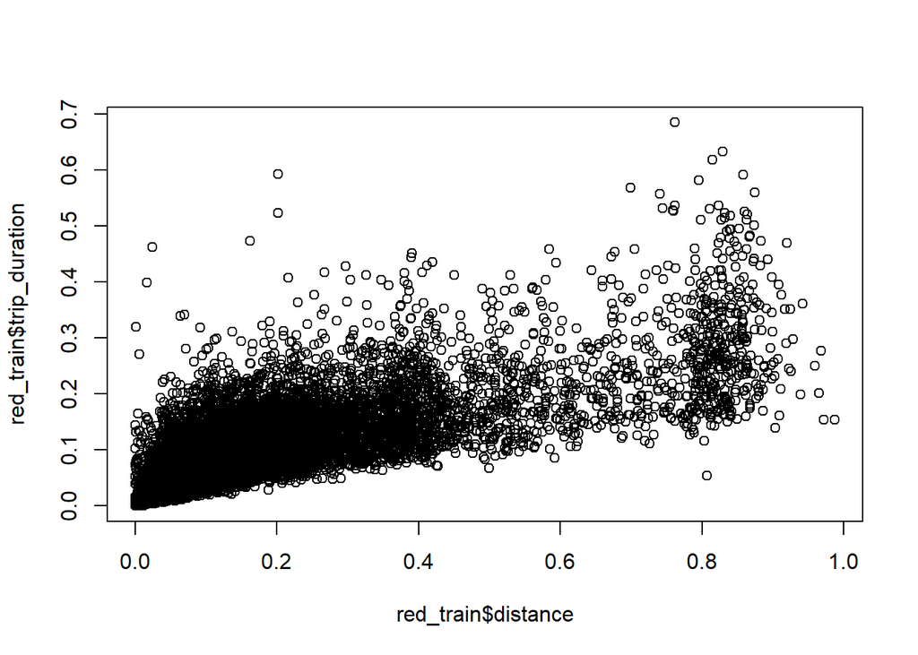

```r
# número de elementos
# menor tamaño -> menor consumo de memoria y tiempo de CPU
n_dataset <- 20000

# reducción de los datos de forma aleatoria
# ¡ADVERTENCIA! En cada ejecución se tomarán unos datos diferentes
red_train <- sample_n(train, n_dataset)
rm(n_dataset)

# representar datos seleccionados
plot(x = red_train$distance, y = red_train$trip_duration)
```

Se crea la matriz de distancias reducida con los 20k elementos. Aún así, esta matriz ocupa en memoria 1,5GB.

```r
# construcción de matriz de distancias
h_dist_matrix <- dist(red_train)

# obtener tamaño de matriz de distancias -> RAM
format(object.size(h_dist_matrix), units = "GB")
```

```
## [1] "1.5 Gb"
```

2. **Aplicar función hclust**

Se aplica la función que permite extraer el agrupamiento jerárquico en un conjunto de datos.

```r
# aplicar hclust para obtener árbol
hc <- hclust(h_dist_matrix)
summary(hc)
```

```
##             Length Class  Mode
## merge       39998  -none- numeric
## height      19999  -none- numeric
## order       20000  -none- numeric
## labels          0  -none- NULL
## method          1  -none- character
## call            2  -none- call
## dist.method     1  -none- character
```

3. **Visualización del dendograma**

Se representa el dendograma o árbol de clústeres. Como podrá observarse, el dendograma dispone de una gran cantidad de niveles debido a la cantidad de datos y sus posibles agrupaciones (20000 datos con una altura de 19999 niveles).

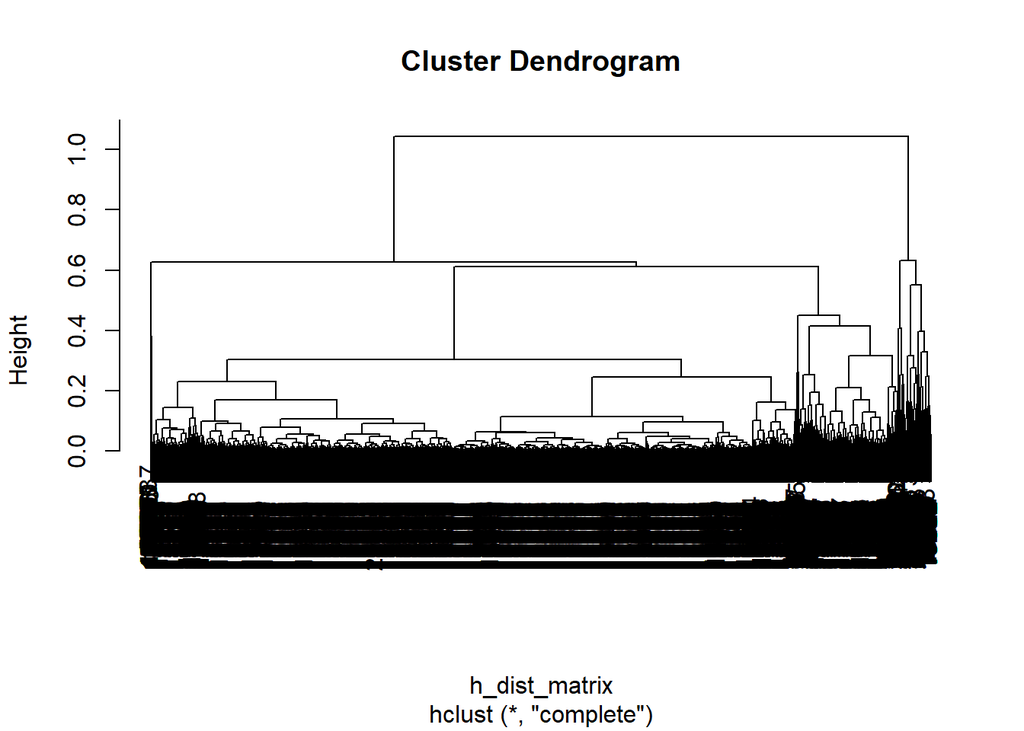

```r
plot(hc)
```

4. **Obtener número óptimo de clusters**

Una vez tenemos el dendograma, será necesario determinar cúantos números de clusters deseamos para cortar el dendograma. Para ello vamos a representar el TSS en relación al número de clusters, para así determinar la mejor opción de forma visual.

Nota: esta función puede tardar varios minutos.

```r
# representa TSS - K (nº de clusters)
# computacionalmente complejo -> ~5 min
fviz_nbclust(red_train, FUN = hcut, method = "wss")
```

[output not shown]

Se ha optado por elegir 4 clusters, ya que a partir de este se estabiliza y no aporta más valor tener más clusters.

5. **Corte del dendograma**

Se corta el dendograma en los 4 clusters que se han determinado previamente. Posteriormente se representa.

```r
# nº clusters seleccionados para corte dendograma
k <- 4

# dendograma cortado
cut_dend <- cutree(hc, k = k)
h_red_train <- mutate(red_train, cluster = cut_dend)
rm(k, cut_dend, hc)
head(h_red_train)
```

|  | trip_duration | distance | cluster |
| --- | --- | --- | --- |
| 1 | 0.02366389 | 0.04261694 | 1 |
| 2 | 0.06236839 | 0.11181339 | 1 |
| 3 | 0.03228718 | 0.04136541 | 1 |
| 4 | 0.03098366 | 0.04194493 | 1 |
| 5 | 0.11370701 | 0.09907438 | 1 |
| 6 | 0.25609145 | 0.36149221 | 1 |

6. **Representación de clusters**

Se representan los clusteres para los puntos datos, tras el corte realizado en el dendograma.

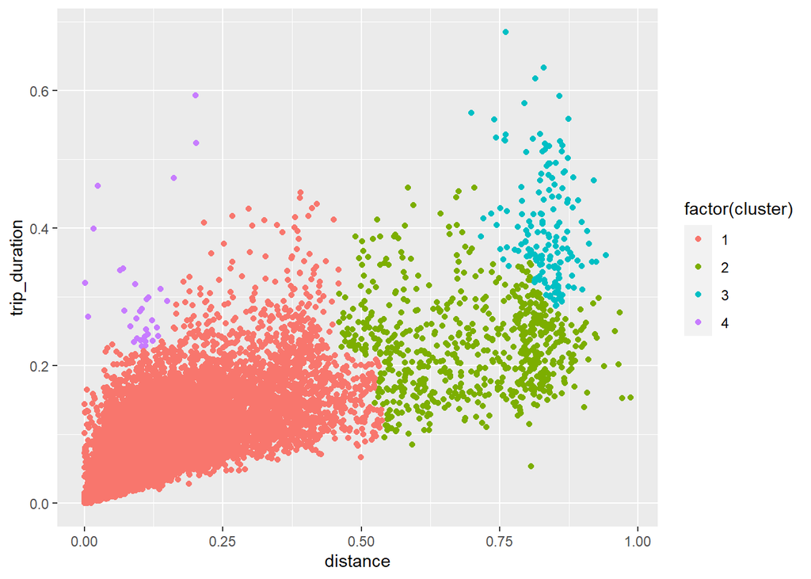

```r
# representa dendograma cortado
ggplot(h_red_train, aes(x = distance, y = trip_duration, color = factor(cluster))) + geom_point()
```

### Clustering basado en densidad

1. **Matriz de distancias:** se obtiene la matriz de distancias de la misma forma que se realiza en el clustering jerárquico.

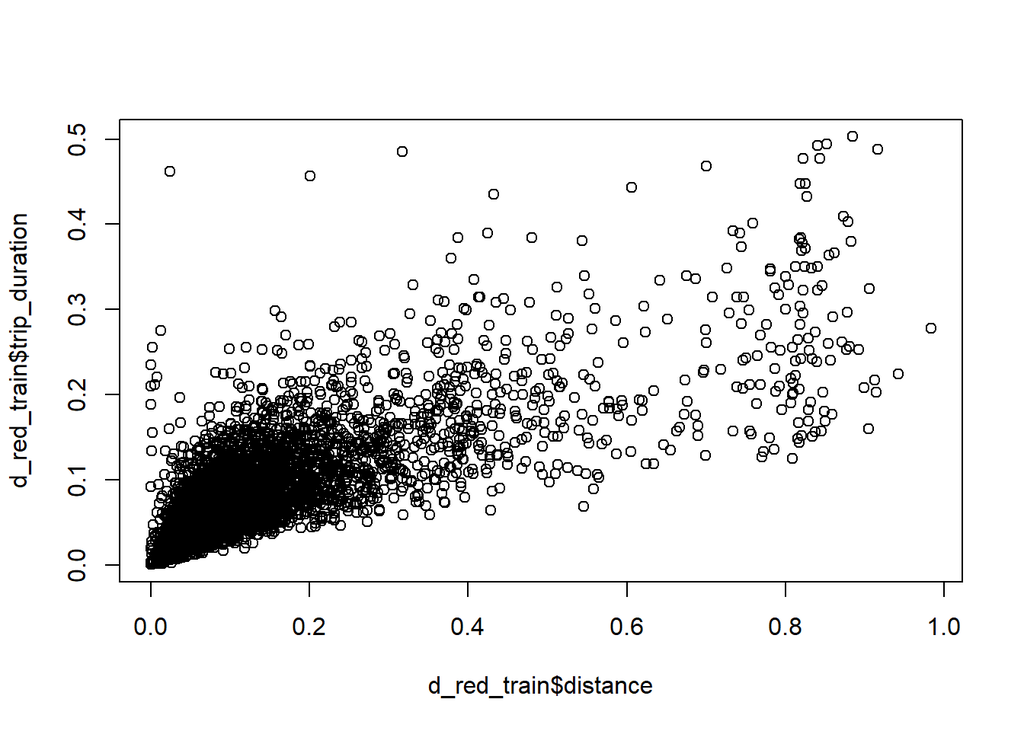

```r
# número de elementos
# menor tamaño -> menor consumo de memoria y tiempo de CPU
n_dataset <- 5000

# reducción de los datos de forma aleatoria
# ¡ADVERTENCIA! En cada ejecución se tomarán unos datos diferentes
d_red_train <- sample_n(train, n_dataset)

# representar datos seleccionados
plot(x = d_red_train$distance, y = d_red_train$trip_duration)
```

```r
# construcción de matriz de distancias
d_dist_matrix <- dist(d_red_train)

# obtener tamaño de matriz de distancias -> RAM
format(object.size(d_dist_matrix), units = "GB")
```

```
## [1] "0.1 Gb"
```

2. **Obtener EPS:** mediante la función kNNdist se puede determinar el EPS que se va a utilizar.

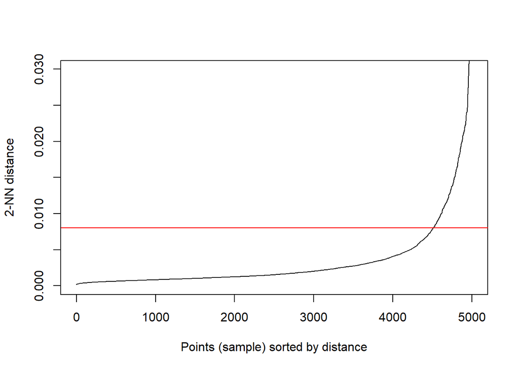

```r
# select number of clusters
k <- 2

# original function
# kNNdistplot(dist_matrix, k)

# custom function
knn_dist <- sort(kNNdist(d_dist_matrix, k))
plot(knn_dist, type = "l", ylab = paste(k, "-NN distance", sep = ""), xlab = "Points (sample) sorted by distance", ylim = c(0, 0.03))
abline(h = .008, col = "red")
```

```r
rm(knn_dist)
```

3. **Aplicar función dbscan**: se aplica la función dbscan para categorizar en los diferentes clusters.

```r
# minimum of points per cluster
min_pts <- n_dataset / 100

# eps: max. dist. entre 2 puntos para ser considerado vecino de otro
eps <- 0.008

# uso de la función dbscan
set.seed(1234)
db <- dbscan(d_dist_matrix, eps, min_pts)
rm(n_dataset, eps, min_pts)
db
```

```
## DBSCAN clustering for 5000 objects.
## Parameters: eps = 0.008, minPts = 50
## Using euclidean distances and borderpoints = TRUE
## The clustering contains 1 cluster(s) and 2135 noise points.
##
##    0    1
## 2135 2865
##
## Available fields: cluster, eps, minPts, dist, borderPoints
```

4. **Representación de clusters:** se representan los diferentes clústeres extraídos mediante densidad.

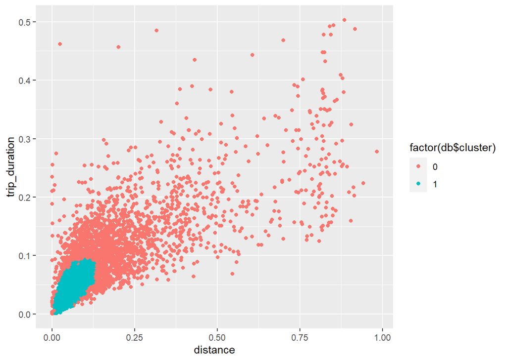

```r
# representación de los clusters
ggplot(d_red_train, aes(x = distance, y = trip_duration, color = factor(db$cluster))) + geom_point()
```

### Comparativa de métodos de clustering

A continuación, se va a comparar las anteriores técnicas de clustering mediante el TSS:

```r
# función cálculo TSS dada matriz de distancia
getTSS <- function(d, cluster) {
  d <- stats::as.dist(d)
  cn <- max(cluster)
  clusterf <- as.factor(cluster)
  clusterl <- levels(clusterf)
  cnn <- length(clusterl)

  if (cn != cnn) {
    warning("cluster renumbered because maximum != number of clusters")
    for (i in 1:cnn) cluster[clusterf == clusterl[i]] <- i
    cn <- cnn
  }
  cwn <- cn
  # Compute total within sum of square
  dmat <- as.matrix(d)
  within.cluster.ss <- 0
  for (i in 1:cn) {
    cluster.size <- sum(cluster == i)
    di <- as.dist(dmat[cluster == i, cluster == i])
    within.cluster.ss <- within.cluster.ss + sum(di^2)/cluster.size
  }
  within.cluster.ss
}

# TSS para k-means
tss_km <- km_train$tot.withinss

# TSS para jerárquico
tss_h <- getTSS(h_dist_matrix, h_red_train$cluster)

# TSS para densidad
tss_d <- getTSS(d_dist_matrix, db$cluster)
```

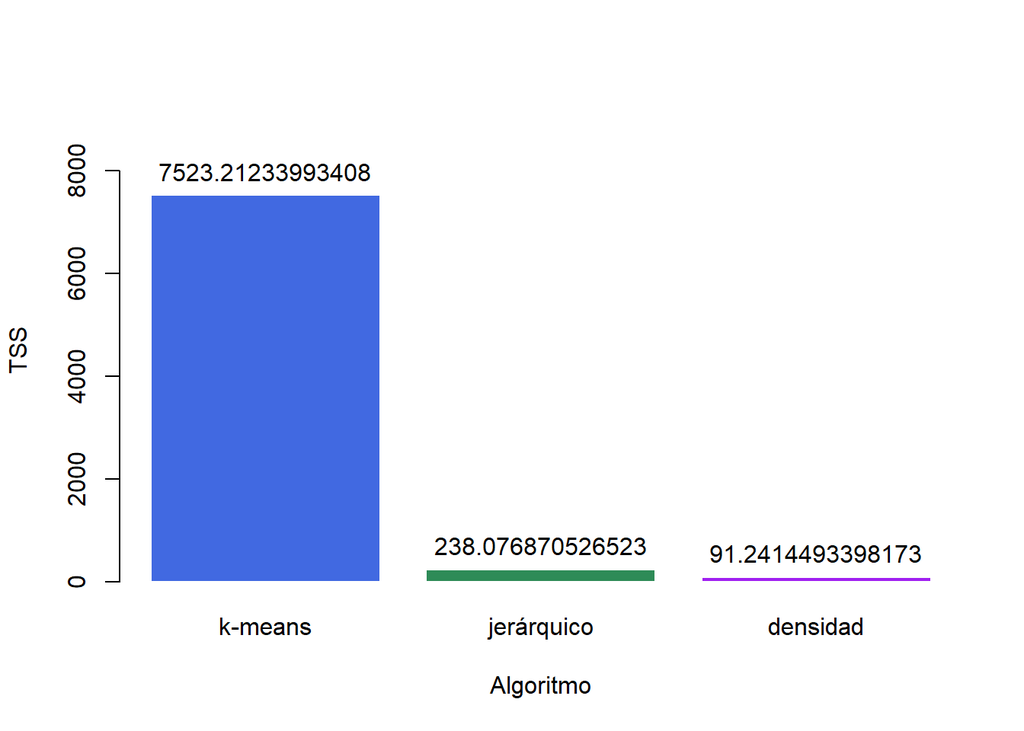

```r
# representa la diferencia entre los algoritmos de clustering
dif_clust <- c(tss_km, tss_h, tss_d)
names_alg_clust <- c("k-means", "jerárquico", "densidad")

my_bar <- barplot(dif_clust, border=F,
     xlab = "Algoritmo", ylab = "TSS",
     names.arg = names_alg_clust,
     col = c("royalblue", "seagreen", "purple"),
     ylim=c(0,9000))
 text(x = my_bar, y = dif_clust, labels = dif_clust, cex=1, pos=3)
```

## Interpretación de los datos

Como hemos visto en los algoritmos anteriores, el número óptimo de clústeres que podemos crear son entorno a 3 y 4. Estos números son correctos, ya que coinciden con los que estabamos buscando.

Nos quedamos con un cluster de 3. Así tenemos un cluster para los viajes rápidos, medios y lentos respecto a la distancia y tiempo del recorrido de los diferentes taxis de Nueva York.

# Métodos auxiliares

## Método de reducción de datos auxiliar

Este método fue usado para intentar equilibrar la carga de datos del dataset, pero disponía del problema que indicaba mayor concentración de puntos justamente en el comienzo de cada uno de los segmentos de distancia.

```r
# 1º conj.
set1 <- sample_n(train %>% filter(distance <= 0.3), 1000)
head(set1)
```

|  | trip_duration | distance |
| --- | --- | --- |
| 1 | 0.02867743 | 0.05280946 |
| 2 | 0.09876667 | 0.12014701 |
| 3 | 0.04782914 | 0.09605358 |
| 4 | 0.06517598 | 0.12807523 |
| 5 | 0.09465557 | 0.09040491 |
| 6 | 0.10979645 | 0.09395822 |

```r
summary(set1)
```

```
##  trip_duration         distance
##  Min.   :0.002406   Min.   :0.00191
##  1st Qu.:0.036699   1st Qu.:0.04704
##  Median :0.058408   Median :0.07396
##  Mean   :0.067401   Mean   :0.09238
##  3rd Qu.:0.089567   3rd Qu.:0.12021
##  Max.   :0.267121   Max.   :0.29937
```

```r
# 2º conj.
set2 <- sample_n(train %>% filter(distance > 0.3 & distance < 0.6), 1000)
head(set2)
```

|  | trip_duration | distance |
| --- | --- | --- |
| 1 | 0.14017848 | 0.3031358 |
| 2 | 0.17818109 | 0.3406996 |
| 3 | 0.10508373 | 0.3389650 |
| 4 | 0.08623283 | 0.3204308 |
| 5 | 0.09415422 | 0.4239517 |
| 6 | 0.15481801 | 0.3398516 |

```r
summary(set2)
```

```
##  trip_duration        distance
##  Min.   :0.03499   Min.   :0.3001
##  1st Qu.:0.12764   1st Qu.:0.3426
##  Median :0.16048   Median :0.3832
##  Mean   :0.17401   Mean   :0.4056
##  3rd Qu.:0.20733   3rd Qu.:0.4540
##  Max.   :0.83947   Max.   :0.5988
```

```r
# 3º conj.
set3 <- sample_n(train %>% filter(distance >= 0.6), 1000)
head(set3)
```

|  | trip_duration | distance |
| --- | --- | --- |
| 1 | 0.5802667 | 0.7583583 |
| 2 | 0.3329991 | 0.8206158 |
| 3 | 0.1790835 | 0.6262418 |
| 4 | 0.1633410 | 0.8358126 |
| 5 | 0.2584979 | 0.8404432 |
| 6 | 0.2444600 | 0.7213209 |

```r
summary(set3)
```

```
##  trip_duration        distance
##  Min.   :0.07711   Min.   :0.6001
##  1st Qu.:0.19242   1st Qu.:0.7231
##  Median :0.24391   Median :0.8033
##  Mean   :0.26418   Mean   :0.7844
##  3rd Qu.:0.31483   3rd Qu.:0.8427
##  Max.   :0.76286   Max.   :0.9953
```

```r
# unir todos los conjuntos
red_train <- rbind(set1, set2, set3)
rm(set1, set2, set3)
head(red_train)
```

|  | trip_duration | distance |
| --- | --- | --- |
| 1 | 0.02867743 | 0.05280946 |
| 2 | 0.09876667 | 0.12014701 |
| 3 | 0.04782914 | 0.09605358 |
| 4 | 0.06517598 | 0.12807523 |
| 5 | 0.09465557 | 0.09040491 |
| 6 | 0.10979645 | 0.09395822 |

```r
summary(red_train)
```

```
##  trip_duration         distance
##  Min.   :0.002406   Min.   :0.00191
##  1st Qu.:0.084077   1st Qu.:0.12035
##  Median :0.154517   Median :0.38317
##  Mean   :0.168528   Mean   :0.42747
##  3rd Qu.:0.229219   3rd Qu.:0.72306
##  Max.   :0.839467   Max.   :0.99531
```

Se representa esta distribución.

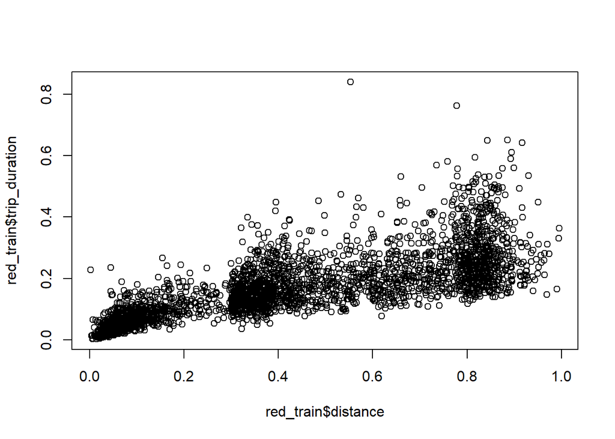

```r
plot(x = red_train$distance, y = red_train$trip_duration)
```

# Autores

## Subgrupo 1 (aprendizaje supervisado)

- **Bruno González Llaga**
  - *Visualización*, *preprocesamiento*
  - *Aprendizaje supervisado*
  - *BigML: documentación y presentación*
- **Carlos González Arenas**
  - *Visualización*, *preprocesamiento*
  - *Aprendizaje supervisado*
  - *BigML: documentación y presentación*
- **Diego Monsalves Vázquez**
  - *Visualización*, *preprocesamiento*
  - *Aprendizaje supervisado*
  - *BigML: documentación y presentación*

## Subgrupo 2 (aprendizaje no supervisado)

- **Daniel Arellano Martínez**
  - *Transformación de datos* en *algoritmos no supervisados*
  - *Clustering con árboles jerárquicos*
  - *Clustering basado en densidad*
  - Documentación: introducción, unificación de trabajo realizado por subgrupos.
- **Víctor Manuel Vázquez García**
  - *Transformación de datos* en *algoritmos no supervisados*
  - *Clustering con k-means*

# Bibliografía

- https://www.datacamp.com/tutorial/hierarchical-clustering-R
- https://uc-r.github.io/hc_clustering